# Phase1_Group61 Project_AirBNB

**Prediciting AirBNB Costs in New York City**

**Name(s) & ID(s) of Group Members:**

1. Mashal Khan
2. Natneal Gizaw

**Table of Contents**

- Introduction

  > Source of Dataset

  > Dataset Information

  > Dataset Features Information

  > Dataset Target Feature Information
- Goals & Objectives
- Data Cleaning and PreProcessing
- Data Visulisations

  > One-Variable Visulisation

  > Two-Variable Visulisation

  > Three-Variable Visulisation
- Insights and Final Conclusions
- References

# Introduction

**Source of Dataset**

This dataset named New York City Airbnb Open data was sourced from Kaggle.com. The dataset contains prices of Airbnb listings within New York City, America, and other relevant information of each listing. The dataset comprises listing activity and its respective metrics in New York City in 2019.

**Data Details and Information**

The New York City Airbnb Open Data is about the listings on Airbnb in New York City in the Year 2019. The dataset itself was originally provided by Airbnb. The dataset contains information about the price per night of listings, locations (neighborhoods & latitude or longitude), names of listings, and their host. Furthermore, it also contains a minimum night of stay for each listing, the type of property of each listing, the number of reviews of each listing, the number of listings from the host over 365 Days, and listing availability over 365 Days. The datasets comprises enough data to conduct regression modelling to predict New York Airbnb prices based on different factors.

Within The New York City Airbnb Open Data, we have identified several features that are not relevant to our analysis and as a result will be dropping them from the dataset

The dataset contains a total of 48,895 Observations and 16 features.

**Dataset Features**

This table contains the features of the Dataset and their respective "properties".

```python
from prettytable import PrettyTable # work has been done on google colab, so pretty table appearance could appear odd
t = PrettyTable()
t.field_names = ['Name of Variable', 'Data Type', 'Units', 'Brief Description']
t.field_names = ['Name of Variable', 'Data Type', 'Units', 'Brief Description']
t.add_row(['neighbourhood_group', 'Nominal Categorical', 'N/A', 'District/borough of listing'])
t.add_row(['neighbourhood', 'Nominal Categorical', 'N/A', 'Provides a specific location as to where in the neighbourhood_group the property is located'])
t.add_row(['room_type', 'Nominal Categorical', 'N/A', 'The type of property the listing is (E.g: Apartement, house, motel etc) '])
t.add_row(['minimum_nights', 'Numeric', 'N/A', 'Minimum nights you can stay at the respective listing'])
t.add_row(['number_of_reviews', 'Numeric', 'N/A', 'Total number of reviews for the listing of the hotel'])
t.add_row(['reviews_per_month', 'Numeric', 'N/A', 'Total number of reviews for the listing for a hotel over a month'])
t.add_row(['calculated_host_listings_count', 'Numeric', 'N/A', 'Number of listings per host within airBNB'])
t.add_row(['availability_365', 'Numeric', 'N/A', 'Shows the availability of the respective listing across 365 days'])
t.add_row(['price', 'Numeric', 'Dollars', 'Price per night at the respective listing (Property) in New York'])
print(t)
# ['Data Type', 'neighbourhood_group', 'neighbourhood', 'room_type', 'minimum_nights', 'number_of_reviews', 'reviews_per_month', 'calculated_host_listings_count', 'availability_365', 'price']
```

```
+--------------------------------+---------------------+---------+---------------------------------------------------------------------------------------------+
|        Name of Variable        |      Data Type      |  Units  |                                      Brief Description                                      |
+--------------------------------+---------------------+---------+---------------------------------------------------------------------------------------------+
|      neighbourhood_group       | Nominal Categorical |   N/A   |                                 District/borough of listing                                 |
|         neighbourhood          | Nominal Categorical |   N/A   | Provides a specific location as to where in the neighbourhood_group the property is located |
|           room_type            | Nominal Categorical |   N/A   |           The type of property the listing is (E.g: Apartement, house, motel etc)           |
|         minimum_nights         |       Numeric       |   N/A   |                    Minimum nights you can stay at the respective listing                    |
|       number_of_reviews        |       Numeric       |   N/A   |                     Total number of reviews for the listing of the hotel                    |
|       reviews_per_month        |       Numeric       |   N/A   |               Total number of reviews for the listing for a hotel over a month              |
| calculated_host_listings_count |       Numeric       |   N/A   |                          Number of listings per host within airBNB                          |
|        availability_365        |       Numeric       |   N/A   |               Shows the availability of the respective listing across 365 days              |
|             price              |       Numeric       | Dollars |               Price per night at the respective listing (Property) in New York              |
+--------------------------------+---------------------+---------+---------------------------------------------------------------------------------------------+
```

### Target Feature

The target feature for the dataset on Airbnb listings is the price. We aim to predict the price of Airbnb listings based on external factors and descriptive features.

## Goals & Objectives

New York, the most expensive city in the U.S is a massive tourist attraction. Attracting many tourists from around the globe, travelers intending to stay in New York City can find tens of thousands of listings on Airbnb for vacation rentals. We want to explore the impact factors like location has on the price of rentals. By identifying patterns that can be used as indicators to determine the cost of vacation rentals, we can gain a better understanding of what gives worth to the different locations of housing, and formulate theories on why tourists are attracted to such places.

These patterns can give us insights into how demand in the housing market is determined, or whether certain tourist attraction's popularity affects or is affected by the rentals. Then we can narrow down the biggest contributing factors to the worth of these rentals and locations. We can accomplish this through insightful data analysis and disaggregation and in the next phase, through predictive modelling. The aim is to derive something meaningful through visualisations of the data, exploration of how different factors can influence each other, and discover what patterns indicate certain results.

Such a statistical model that would predict the prices of Airbnb listings would serve to the advantage of travelers or any person considering to use hotels. The model would also be beneficial for economists who want to determine the indicators of housing market health. Banks may also benefit by being able to assess the financial prospects of mortgages they offer.

# Data Cleaning and Preprocessing

We are going to commence cleaning and preprocessing the dataset to set it up for predective modelling.

We will begin by:

- Read Data from GitHub Repository ( [Githhub](https://raw.githubusercontent.com/Parth-Kulkarni05/Maths_Project/main/AB_NYC_2019.csv) )
- We will import all necessary libraries that we are going to be using in this task

```python
import warnings
warnings.filterwarnings("ignore")
# Set up filter warnings to prevent uncessary warnings from displaying

import numpy as np
import pandas as pd
pd.set_option('display.max_columns', None)
# Ensures that Pandas DataFrame Displays Bigger

import seaborn as sns
import matplotlib.pyplot as plt
%matplotlib inline
%config InlineBackend.figure_format='retina'
plt.style.use('ggplot')
```

```python
df = pd.read_csv("AB_NYC_2019.csv")
# Dataset is now stored in a Pandas Dataframe
```

Now lets check if the dataframe has saved and loaded correctly.

For this will we display the shape and the first 5 rows of the DataFrame

```python
df.shape
```

```
(48895, 16)
```

Now lets take a look by randomly sampling 5 rows from the DataFrame

```python
df.sample(5)
```

|  | id | name | host_id | host_name | neighbourhood_group | neighbourhood | latitude | longitude | room_type | price | minimum_nights | number_of_reviews | last_review | reviews_per_month | calculated_host_listings_count | availability_365 |
| --- | --- | --- | --- | --- | --- | --- | --- | --- | --- | --- | --- | --- | --- | --- | --- | --- |
| 41881 | 32554699 | 1718双个房 | 119692067 | Qiulan | Brooklyn | Sunset Park | 40.64333 | -74.00227 | Private room | 50 | 1 | 10 | 2019-06-20 | 3.16 | 3 | 71 |
| 22408 | 18095883 | Charming 2 Bedroom home close to Airport and City | 70774951 | Farhan | Queens | East Elmhurst | 40.76745 | -73.87915 | Entire home/apt | 125 | 1 | 138 | 2019-06-23 | 6.92 | 3 | 111 |
| 5979 | 4377929 | Spacious 1Br in East Village | 7245580 | David | Manhattan | East Village | 40.72627 | -73.98303 | Entire home/apt | 198 | 4 | 180 | 2019-06-18 | 3.22 | 1 | 269 |
| 4149 | 2683455 | 4BR Family apt 15 min to Manhattan | 1273385 | Cecile | Queens | Long Island City | 40.74749 | -73.92089 | Entire home/apt | 155 | 3 | 4 | 2015-10-13 | 0.07 | 1 | 0 |
| 18759 | 14851530 | Eclectic Prime Williamsburg Space | 50374022 | Elana | Brooklyn | Williamsburg | 40.71254 | -73.96411 | Private room | 100 | 3 | 2 | 2017-05-22 | 0.06 | 2 | 0 |

We will now proceed with the basic steps such as

- Removing ID Columns
- Removing irrelevant features
- Changing Column Names

```python
df = df.drop(['id', 'name', 'host_id', 'host_name', 'latitude', 'longitude', 'last_review'], axis=1)
df = df.rename(columns={'price': 'price_per_night', 'minimum_nights' : 'minimum_nights_to_book'})
df.head()
```

|  | neighbourhood_group | neighbourhood | room_type | price_per_night | minimum_nights_to_book | number_of_reviews | reviews_per_month | calculated_host_listings_count | availability_365 |
| --- | --- | --- | --- | --- | --- | --- | --- | --- | --- |
| 0 | Brooklyn | Kensington | Private room | 149 | 1 | 9 | 0.21 | 6 | 365 |
| 1 | Manhattan | Midtown | Entire home/apt | 225 | 1 | 45 | 0.38 | 2 | 355 |
| 2 | Manhattan | Harlem | Private room | 150 | 3 | 0 | NaN | 1 | 365 |
| 3 | Brooklyn | Clinton Hill | Entire home/apt | 89 | 1 | 270 | 4.64 | 1 | 194 |
| 4 | Manhattan | East Harlem | Entire home/apt | 80 | 10 | 9 | 0.10 | 1 | 0 |

- ID columns are irrelvant to this project and have no use towards the aim of the task or to the target variable, therefore they are removed.
- Other columns such as name, host_id, host_name, and last review are also irrelevant to the project and are no use to be compared against the target variable, therefore they are removed.
- The latitude and longitude columns were dropped as they are redudant because of the neighbourhood feature.
- Columns were renamed for clarity purposes.

Now we will continue the data cleaning and preprocessing by

- Checking for outliers and unsusal Values
- Check for Missing Values and make sure they are either imputed or rows containing them are dropped
- Sampling the data to 5000 rows

```python
df.isna().sum()
```

```
neighbourhood_group                   0
neighbourhood                         0
room_type                             0
price_per_night                       0
minimum_nights_to_book                0
number_of_reviews                     0
reviews_per_month                 10052
calculated_host_listings_count        0
availability_365                      0
dtype: int64
```

```python
df = df.dropna()
```

Missing values were only found within the reviews_per_month column. We decided to drop all rows contaning missing values, as values with missing values within the reviews_per_month column will also contain 0 reviews. Therefore, it wouldn't make sense to impute for these missing values and also due to the context of the dataset it could potentially lead to an inaccurate representation of each listing and also because we could potentially intoduce bias from imputation

We will now check to ensure that all columns contain the right and expected data-types, to prevent any issues during visulisations and data manipulation in the later stages of the task.

```python
df.dtypes
```

```
neighbourhood_group                object
neighbourhood                      object
room_type                          object
price_per_night                     int64
minimum_nights_to_book              int64
number_of_reviews                   int64
reviews_per_month                 float64
calculated_host_listings_count      int64
availability_365                    int64
dtype: object
```

All data-types are as required

We will now provide a summary of the categorical variables to identify number of obeservations in each categorical variable, the count of unique values and and frequencies to get better idea of the catergorical values within the dataset

```python
df.describe(include = 'object')
```

|  | neighbourhood_group | neighbourhood | room_type |
| --- | --- | --- | --- |
| count | 38843 | 38843 | 38843 |
| unique | 5 | 218 | 3 |
| top | Manhattan | Williamsburg | Entire home/apt |
| freq | 16632 | 3163 | 20332 |

We want to check for any unusual values in our catergorical data. As per the columns below, there are no unusual values present within the categorical features

```python
cols = df.select_dtypes(include='object').columns
for col in cols:
    print('Unique values for ' + col)
    print(df[col].unique())
    print()
```

```
Unique values for neighbourhood_group
['Brooklyn' 'Manhattan' 'Queens' 'Staten Island' 'Bronx']

Unique values for neighbourhood
['Kensington' 'Midtown' 'Clinton Hill' 'East Harlem' 'Murray Hill'
 'Bedford-Stuyvesant' "Hell's Kitchen" 'Upper West Side' 'Chinatown'
 'South Slope' 'West Village' 'Williamsburg' 'Fort Greene' 'Chelsea'
 'Crown Heights' 'Park Slope' 'Windsor Terrace' 'Inwood' 'East Village'
 'Harlem' 'Greenpoint' 'Bushwick' 'Lower East Side'
 'Prospect-Lefferts Gardens' 'Long Island City' 'Kips Bay' 'SoHo'
 'Upper East Side' 'Prospect Heights' 'Washington Heights' 'Woodside'
 'Flatbush' 'Brooklyn Heights' 'Carroll Gardens' 'Gowanus' 'Flatlands'
 'Cobble Hill' 'Flushing' 'Boerum Hill' 'Sunnyside' 'DUMBO' 'St. George'
 'Highbridge' 'Financial District' 'Ridgewood' 'Morningside Heights'
 'Jamaica' 'Middle Village' 'NoHo' 'Ditmars Steinway' 'Flatiron District'
 'Roosevelt Island' 'Greenwich Village' 'Little Italy' 'East Flatbush'
 'Tompkinsville' 'Astoria' 'Eastchester' 'Kingsbridge' 'Two Bridges'
 'Queens Village' 'Rockaway Beach' 'Forest Hills' 'Nolita' 'Woodlawn'
 'University Heights' 'Gramercy' 'Allerton' 'East New York'
 'Theater District' 'Concourse Village' 'Sheepshead Bay' 'Emerson Hill'
 'Fort Hamilton' 'Bensonhurst' 'Tribeca' 'Shore Acres' 'Sunset Park'
 'Concourse' 'Elmhurst' 'Brighton Beach' 'Jackson Heights' 'Cypress Hills'
 'St. Albans' 'Arrochar' 'Rego Park' 'Wakefield' 'Clifton' 'Bay Ridge'
 'Graniteville' 'Spuyten Duyvil' 'Stapleton' 'Briarwood' 'Ozone Park'
 'Columbia St' 'Vinegar Hill' 'Mott Haven' 'Longwood' 'Canarsie'
 'Battery Park City' 'Civic Center' 'East Elmhurst' 'New Springville'
 'Morris Heights' 'Arverne' 'Gravesend' 'Tottenville' 'Mariners Harbor'
 'Concord' 'Borough Park' 'Bayside' 'Downtown Brooklyn' 'Port Morris'
 'Fieldston' 'Kew Gardens' 'Midwood' 'College Point' 'Mount Eden'
 'City Island' 'Glendale' 'Red Hook' 'Richmond Hill' 'Maspeth'
 'Port Richmond' 'Williamsbridge' 'Soundview' 'Woodhaven' 'Co-op City'
 'Stuyvesant Town' 'Parkchester' 'North Riverdale' 'Dyker Heights'
 'Bronxdale' 'Sea Gate' 'Riverdale' 'Kew Gardens Hills' 'Bay Terrace'
 'Norwood' 'Claremont Village' 'Whitestone' 'Fordham' 'Bayswater'
 'Navy Yard' 'Brownsville' 'Eltingville' 'Mount Hope' 'Clason Point'
 'Lighthouse Hill' 'Springfield Gardens' 'Howard Beach' 'Belle Harbor'
 'Jamaica Estates' 'Van Nest' 'Bellerose' 'Fresh Meadows' 'Morris Park'
 'West Brighton' 'Far Rockaway' 'South Ozone Park' 'Tremont' 'Corona'
 'Great Kills' 'Manhattan Beach' 'Marble Hill' 'Dongan Hills'
 'East Morrisania' 'Hunts Point' 'Neponsit' 'Pelham Bay' 'Randall Manor'
 'Throgs Neck' 'Todt Hill' 'West Farms' 'Silver Lake' 'Laurelton'
 'Grymes Hill' 'Holliswood' 'Pelham Gardens' 'Rosedale'
 'Castleton Corners' 'Edgemere' 'New Brighton' 'Baychester' 'Melrose'
 'Bergen Beach' 'Cambria Heights' 'Richmondtown' 'Howland Hook'
 'Schuylerville' 'Coney Island' "Prince's Bay" 'South Beach' 'Bath Beach'
 'Midland Beach' 'Jamaica Hills' 'Oakwood' 'Castle Hill' 'Douglaston'
 'Huguenot' 'Edenwald' 'Belmont' 'Grant City' 'Westerleigh' 'Morrisania'
 'Bay Terrace, Staten Island' 'Westchester Square' 'Little Neck'
 'Rosebank' 'Unionport' 'Mill Basin' 'Hollis' 'Arden Heights'
 "Bull's Head" 'Olinville' 'Rossville' 'Breezy Point' 'Willowbrook'
 'New Dorp Beach']

Unique values for room_type
['Private room' 'Entire home/apt' 'Shared room']
```

```python
df.describe()
```

|  | price_per_night | minimum_nights_to_book | number_of_reviews | reviews_per_month | calculated_host_listings_count | availability_365 |
| --- | --- | --- | --- | --- | --- | --- |
| count | 38843.000000 | 38843.000000 | 38843.000000 | 38843.000000 | 38843.000000 | 38843.000000 |
| mean | 142.317947 | 5.868059 | 29.297557 | 1.373221 | 5.164457 | 114.882888 |
| std | 196.945624 | 17.384784 | 48.186374 | 1.680442 | 26.295665 | 129.543636 |
| min | 0.000000 | 1.000000 | 1.000000 | 0.010000 | 1.000000 | 0.000000 |
| 25% | 69.000000 | 1.000000 | 3.000000 | 0.190000 | 1.000000 | 0.000000 |
| 50% | 101.000000 | 2.000000 | 9.000000 | 0.720000 | 1.000000 | 55.000000 |
| 75% | 170.000000 | 4.000000 | 33.000000 | 2.020000 | 2.000000 | 229.000000 |
| max | 10000.000000 | 1250.000000 | 629.000000 | 58.500000 | 327.000000 | 365.000000 |

To check for outliers within the dataset, using the .describe() function will be applied to populate summary stastics. Outliers were identifed within this dataset.

Upon analysis, the price_per_night does contain outliers. This could be because of bad data, wrong user input or is deliberate and geninune. Treating the price_per_night variable is essential to remove any potential skewness and any siginfiance to the price_per_night variable.

Furthermore, calculated_host_listings_counts contained outliers, this could simply be because of bad data, wrong user input and or is deliberate or geninue, but treating the outliers ensures that no unncessary potential skweness is introduced within the data and for further data visulisations

As you may see that minimum_nights_to_book, number_of_reviews and reviews_per_month also contained outliers. However, we decided not to treat these features for outliers because treating them for outliers does not make sense to the context of the dataset, because minimum nights to book can be high depending on the host's preferences and treating reviews for outliers could diminish the listings overall "value". Furthermore, to still recognise the potenital of bad data or input error data we filtered down the values in Minimum Nights to less than 366 days to ensure that any bad or input data is avidoed without dimnishing the overall value of a listing. Therefore, as it would result in an inaccurate representation of those respective features we did not treat them for outliers.

```python
# Treating for Outliers for minimum_nights_to_book variable, calculated host_listings_count and price_per_night #

cols = ['calculated_host_listings_count', 'price_per_night'] # one or more

Q1 = df[cols].quantile(0.25)
Q3 = df[cols].quantile(0.75)
IQR = Q3 - Q1

df_airbnb = df[~((df[cols] < (Q1 - 1.5 * IQR)) |(df[cols] > (Q3 + 1.5 * IQR))).any(axis=1)]
df_airbnb = df_airbnb.loc[(df_airbnb['minimum_nights_to_book'] < 366)]


df_airbnb.describe() # Display Summary Statistics after removing outliers
```

|  | price_per_night | minimum_nights_to_book | number_of_reviews | reviews_per_month | calculated_host_listings_count | availability_365 |
| --- | --- | --- | --- | --- | --- | --- |
| count | 31863.000000 | 31863.000000 | 31863.000000 | 31863.000000 | 31863.000000 | 31863.000000 |
| mean | 119.309010 | 4.857829 | 29.885604 | 1.344031 | 1.324357 | 95.064212 |
| std | 64.460292 | 13.015932 | 48.645930 | 1.627597 | 0.608169 | 120.728280 |
| min | 0.000000 | 1.000000 | 1.000000 | 0.010000 | 1.000000 | 0.000000 |
| 25% | 70.000000 | 2.000000 | 3.000000 | 0.180000 | 1.000000 | 0.000000 |
| 50% | 100.000000 | 2.000000 | 10.000000 | 0.680000 | 1.000000 | 28.000000 |
| 75% | 151.000000 | 4.000000 | 34.000000 | 2.000000 | 1.000000 | 178.000000 |
| max | 321.000000 | 365.000000 | 629.000000 | 20.940000 | 3.000000 | 365.000000 |

```python
df_airbnb.shape
```

```
(31863, 9)
```

Random Sampling:

```python
df_airbnb = df_airbnb.sample(n = 5000, random_state = 1234 )
```

The data is now clean and in a state that is ready to be visualised to explore our goals and objectives by analysing the features and comparing it to the target variable or feature.

# Data Visualisations

[interactive chart not shown]

**One Variable Visualisations**

```python
sns.set(rc = {'figure.figsize':(15,8)}) # Set Size for Seaborn Plots
```

**Count of listings across boroughs**

These are the number of listings across each New York district. We can see both Manhattan and Brooklyn have the highest number of listings in New York, much more than the other boroughs.

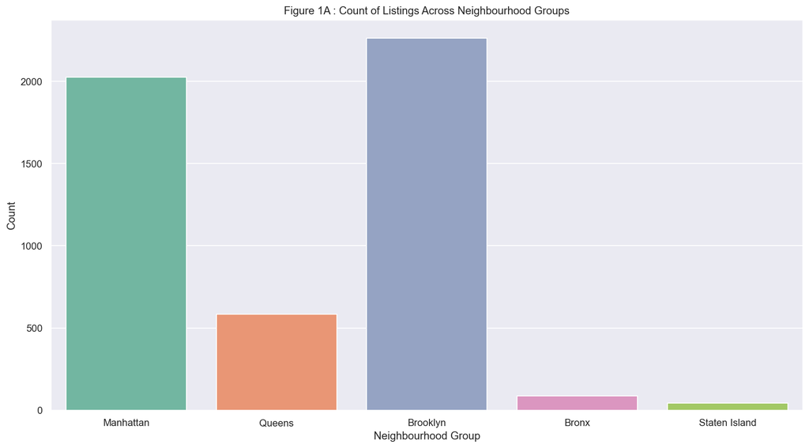

```python
# count plot along y axis
sns.countplot(x = 'neighbourhood_group', data = df_airbnb,  palette = "Set2").set_title('Figure 1A : Count of Listings Across Neighbourhood Groups')
plt.xlabel('Neighbourhood Group')
plt.ylabel('Count')
plt.show(); # Show the plot
```

**Count of room types across New York, Airbnb**

This is a count of the variety of room types in New York. We can see shared rooms are much rarer than private rooms and entire homes.

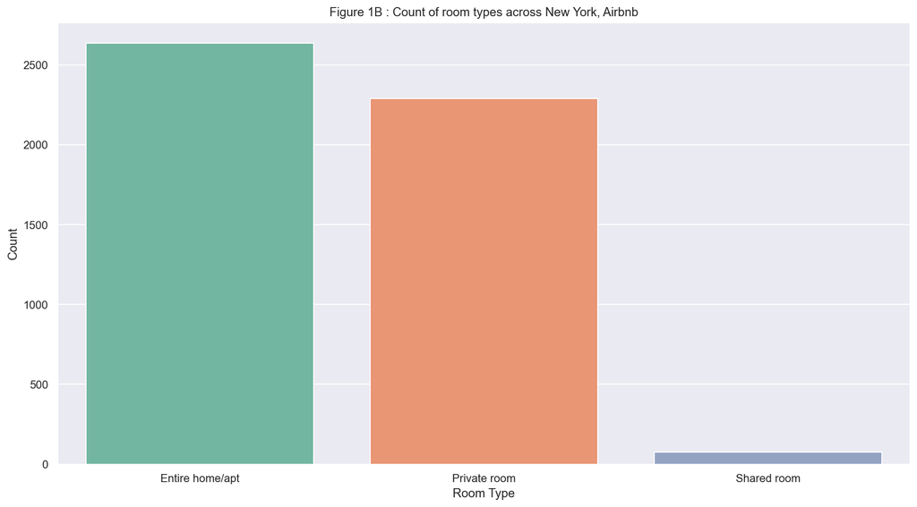

```python
sns.countplot(x = 'room_type', data = df_airbnb,  palette = "Set2").set_title('Figure 1B : Count of room types across New York, Airbnb')
plt.xlabel('Room Type')
plt.ylabel('Count')
plt.show();
```

**Avaiability across the year**

This histogram shows the most common listings based on the number of days it's available for booking across the year. We can see that most listings are only available for a month or two throughout the year.

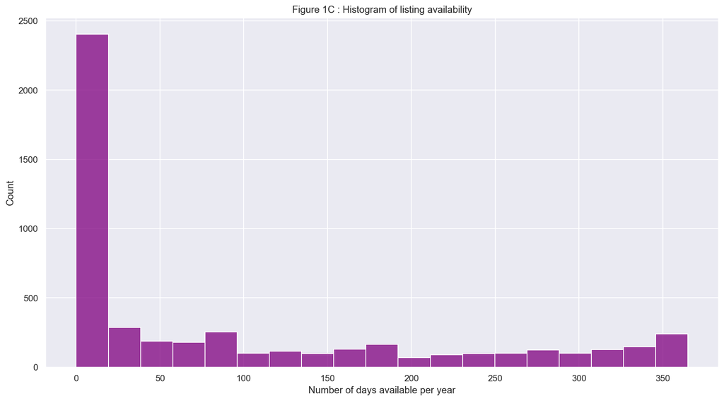

```python
sns.histplot(x = 'availability_365',  data = df_airbnb,  palette = "Set2", color='purple').set_title('Figure 1C : Histogram of listing availability')
plt.xlabel('Number of days available per year')
plt.ylabel('Count')
plt.show();
```

**Density of New York Airbnb listing prices**

This is a KDE histogram for the prices of all Airbnb listings in New York. We can see most common property costs are between \$50 and \$100.

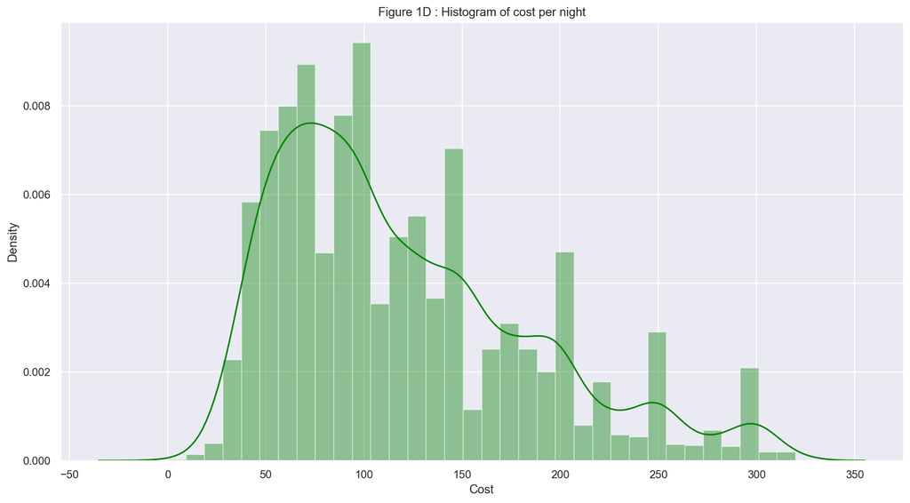

```python
sns.distplot(df_airbnb['price_per_night'], kde = True, bins = None, color = 'green').set_title('Figure 1D : Histogram of cost per night')
plt.xlabel('Cost')
plt.show();
```

‍

**Two-Variable Visulisations**

**Box plot of price vs room type**

This box plot shows the how the price varies based on the room type of the listing. We can see that entire homes/apartments are significantly more expensive than other room types.

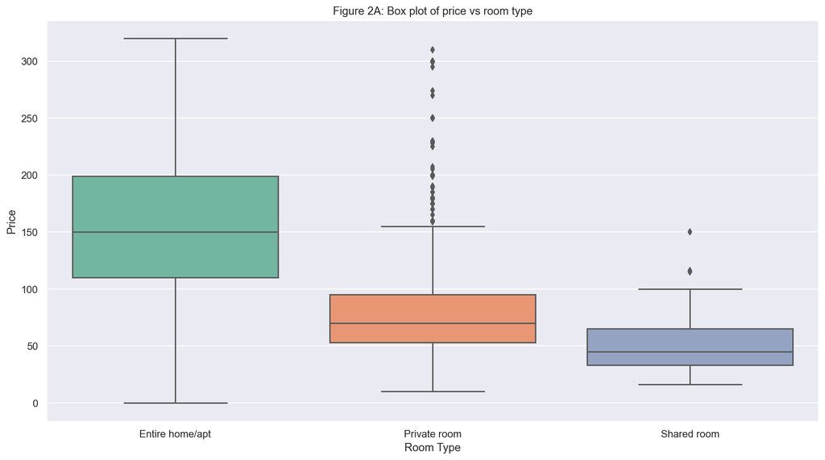

```python
sns.set(rc = {'figure.figsize':(15,8)})

sns.boxplot(x="room_type",
            y="price_per_night",
            data=df_airbnb,
           palette = "Set2").set_title('Figure 2A: Box plot of price vs room type')
plt.xlabel('Room Type')
plt.ylabel('Price')
plt.show();
```

**Cat plot of price vs borough**

This cat plot shows the prices of Airbnb listings across different boroughs in New York. We can see Brooklyn and Manhattan, which as shown above has more listings than the other districts, and also has the most expensive listings.

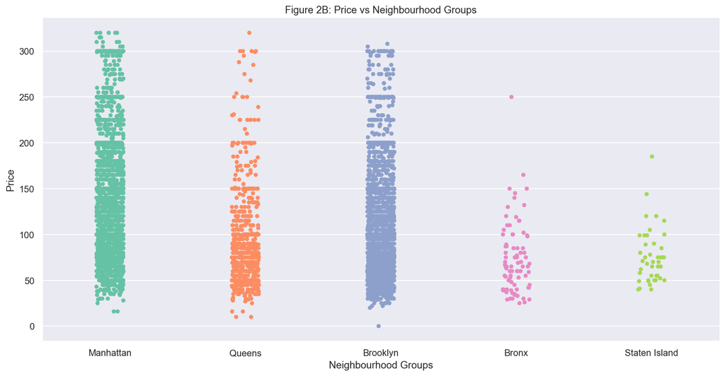

```python
sns.catplot(x="neighbourhood_group",
            y="price_per_night",
            data=df_airbnb,           # Seaborn cat plot with
           palette = "Set2",
           jitter = True,height=6, aspect=2)
plt.title('Figure 2B: Price vs Neighbourhood Groups')
plt.xlabel('Neighbourhood Groups')
plt.ylabel('Price')

plt.show();
```

**Scatterplot of Price Per Night vs Minimum Nights To Book**

This scatterplot shows that there is no correlation between the price per night and the minimum nights required to book a listing.

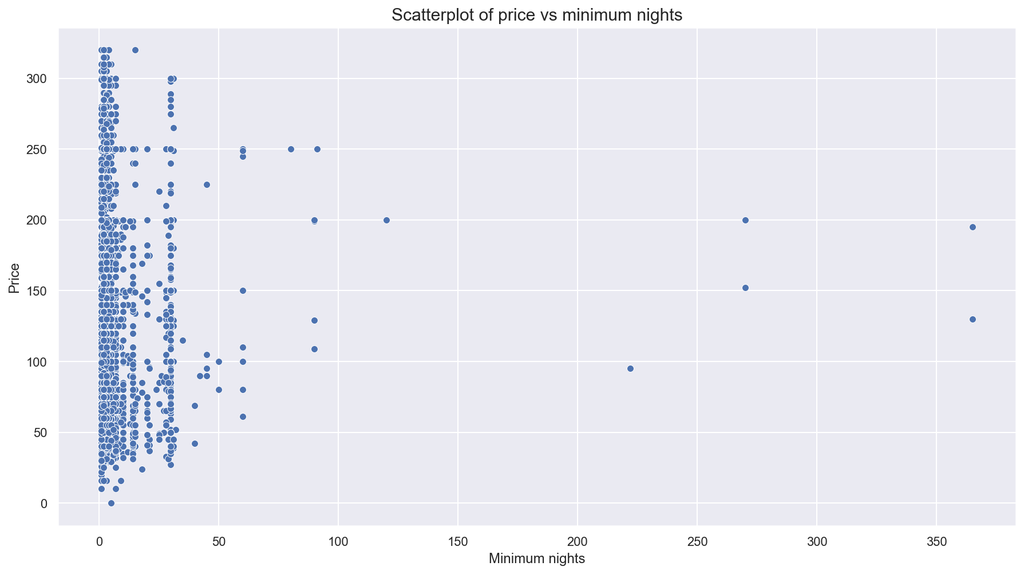

```python
ax = sns.scatterplot(x = 'minimum_nights_to_book', y= 'price_per_night', data = df_airbnb, palette="Set2")
plt.title('Scatterplot of price vs minimum nights', fontsize = 15)
plt.xlabel('Minimum nights')
plt.ylabel('Price')
plt.show();
```

**Top 10 Neighbourhoods with most Listings vs Average Prices** **Top 10 Neighbourhoods with least Listings vs Average Prices**

The barplots shows that the listing per neighbourhood doesnt have an affect on the average price per night of the neighbourhood.

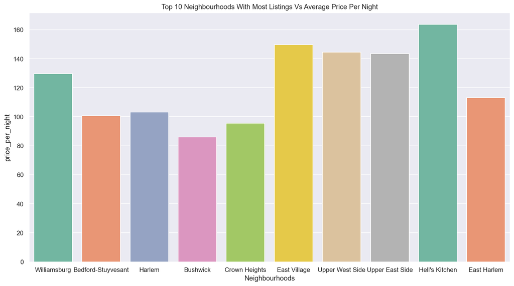

```python
k = df_airbnb['neighbourhood'].value_counts()[:10].sort_values(ascending = False)
k = k.index.tolist()
x =  df_airbnb.groupby('neighbourhood')['price_per_night'].mean()
y = x[k]

sns.set(rc = {'figure.figsize':(15,8)})

plt.xlabel('Neighbourhoods')

ax = sns.barplot(x=k, y=y, data=df_airbnb,  palette = "Set2").set_title('Top 10 Neighbourhoods With Most Listings Vs Average Price Per Night')
```

[figure not shown]

```python
k = df_airbnb['neighbourhood'].value_counts()[-10:].sort_values(ascending = False)
k = k.index.tolist()
x =  df_airbnb.groupby('neighbourhood')['price_per_night'].mean()
y = x[k]

sns.set(rc = {'figure.figsize':(15,8)})

plt.xlabel('Top 5 Neighbourhoods with Most Listings In New York City')

ax = sns.barplot(x=k, y=y, data=df_airbnb,  palette = "Set2").set_title('Neighbourhoods With Most Listings Vs Average Price Per Night')
```

**Histogram of price compared with number of host listings**

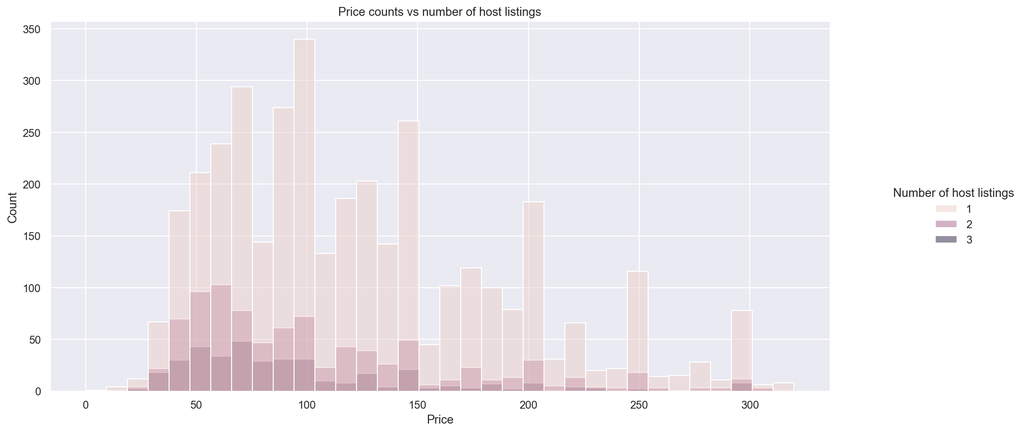

```python
sns.displot(x=df_airbnb['price_per_night'],hue=df_airbnb['calculated_host_listings_count'], height = 6, aspect = 2)._legend.set_title('Number of host listings');
plt.title("Price counts vs number of host listings")
plt.xlabel('Price')
plt.show();
```

‍

```python
sns.set(rc = {'figure.figsize':(10,10)})
```

**Three-Variable Visulisations**

**Scatterplot analysis of borough and monthly reviews on price**

This scatterplot shows there seems to be a weak correlation between the price of listings and reviews per month.

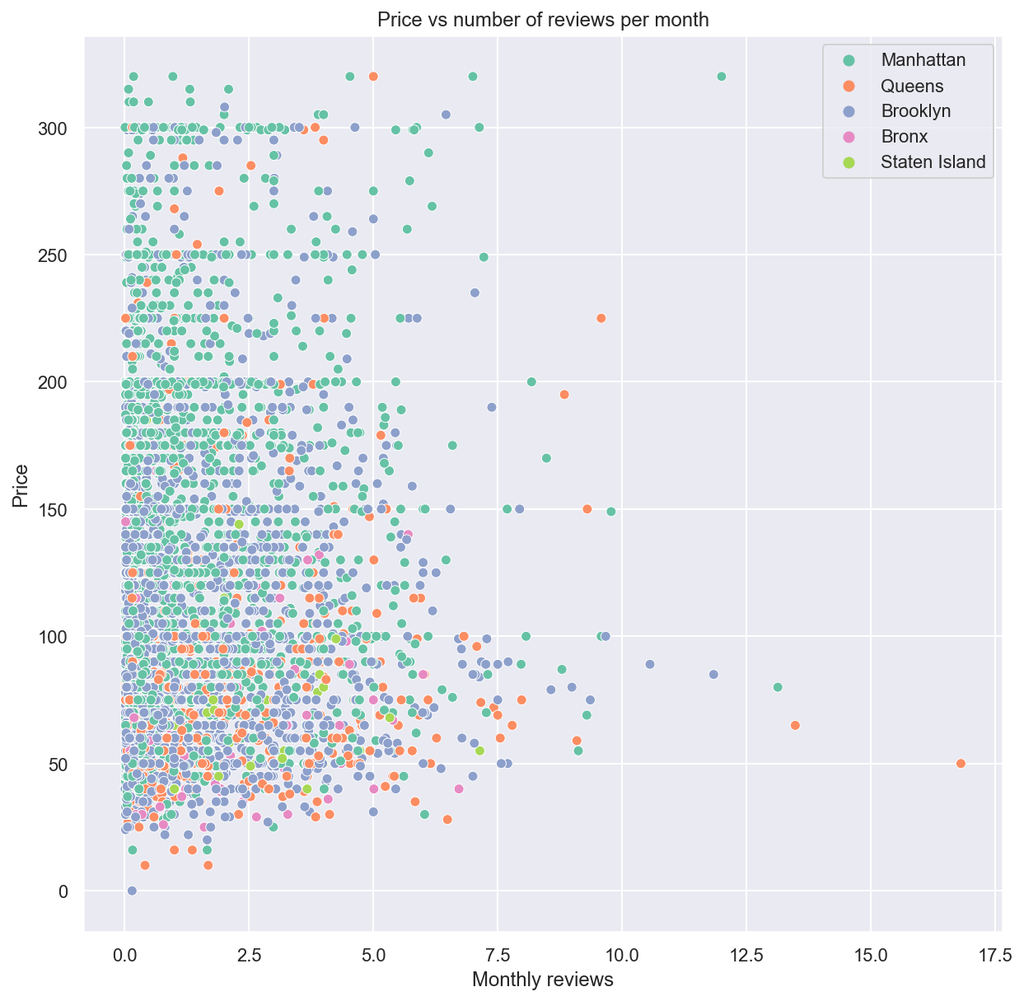

```python
sns.scatterplot(y="price_per_night",
            x="reviews_per_month",
            hue="neighbourhood_group",
            data=df_airbnb,
            palette="Set2");
plt.legend(bbox_to_anchor=(1,1))
plt.title("Price vs number of reviews per month")
plt.xlabel('Monthly reviews')
plt.ylabel('Price')
plt.show();
```

**Scatterplot analysis of availability and room type on price**

This scatterplot shows roughly no correlation between the availability of a listing throughout the year.

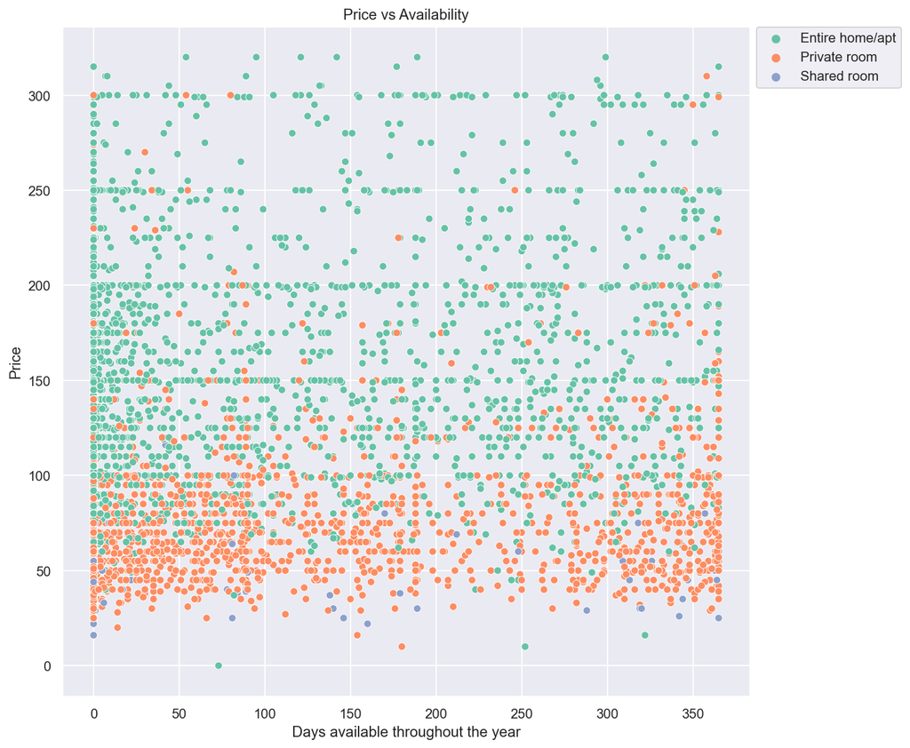

```python
sns.scatterplot(y="price_per_night",
            x="availability_365",
            hue="room_type",
            data=df_airbnb,
            palette="Set2");
plt.legend(bbox_to_anchor=(1, 1.01))
plt.title("Price vs Availability")
plt.xlabel('Days available throughout the year')
plt.ylabel('Price')
plt.show();
```

**Scatterplot analysis of total listing reviews and number of host listings on price**

This scatterplot illustrates roughly no correlation between price and number of reviews.

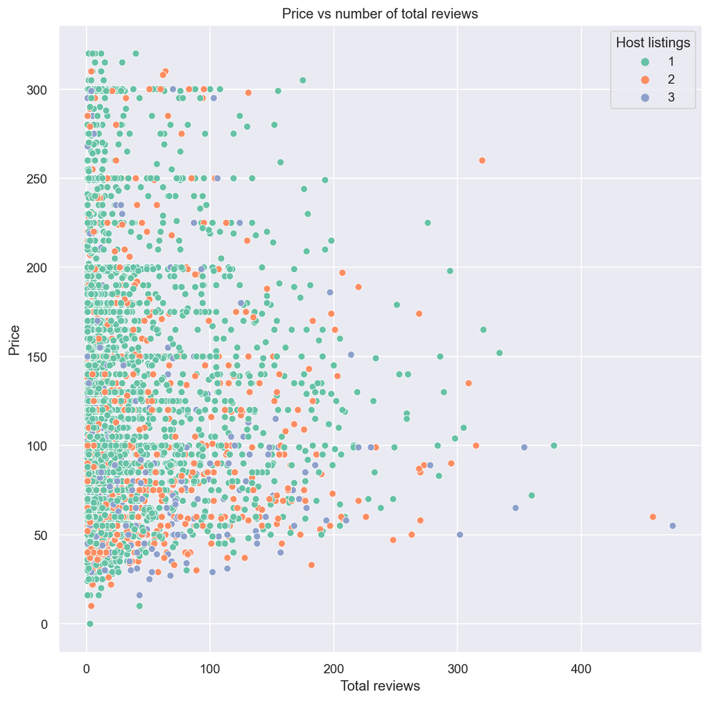

```python
sns.scatterplot(y="price_per_night",
            x="number_of_reviews",
            hue="calculated_host_listings_count",
            data=df_airbnb,
            palette="Set2")
plt.legend(title='Host listings',bbox_to_anchor=(1, 1))
plt.title("Price vs number of total reviews")
plt.xlabel('Total reviews')
plt.ylabel('Price')
plt.show();
```

**Scatterplot analysis of minimum nights and Neighbourhood Groups on price**

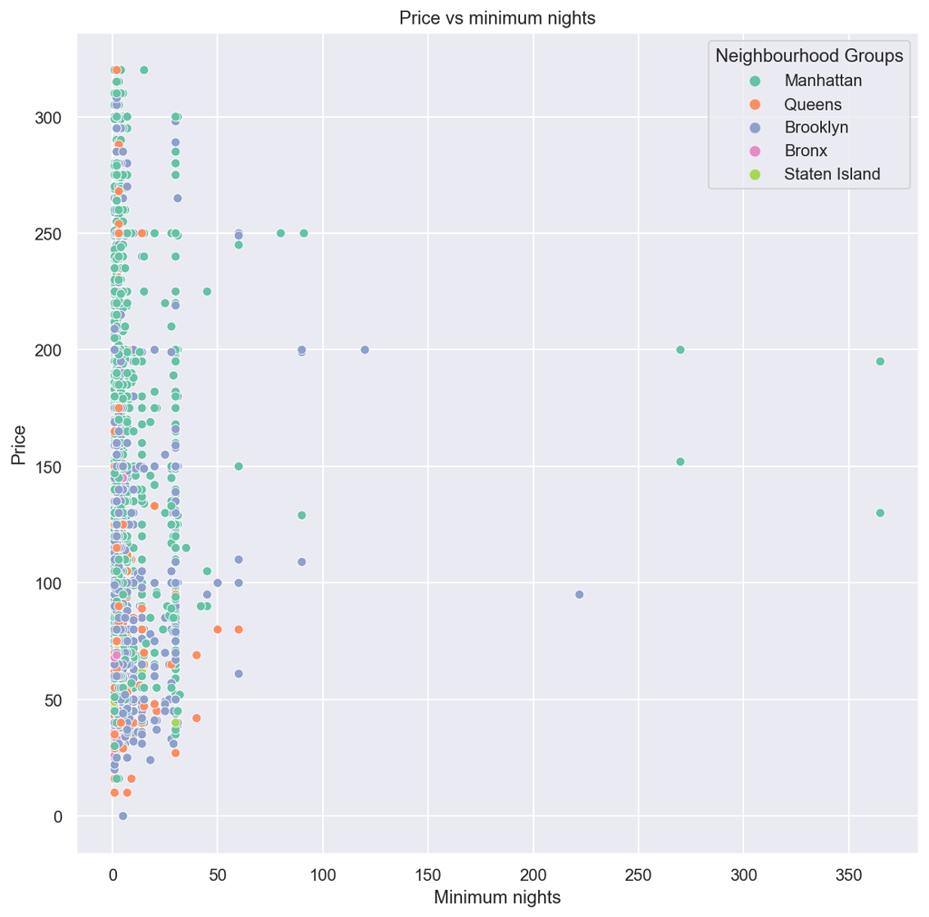

```python
sns.scatterplot(y="price_per_night",
            x="minimum_nights_to_book",
            hue="neighbourhood_group",
            data=df_airbnb,
            palette="Set2");
plt.title("Price vs minimum nights")
plt.xlabel('Minimum nights')
plt.ylabel('Price')
plt.legend(title='Neighbourhood Groups')
plt.show();
```

**Boxplot of Price broken down by Neighbourhood Groups and Room Type**

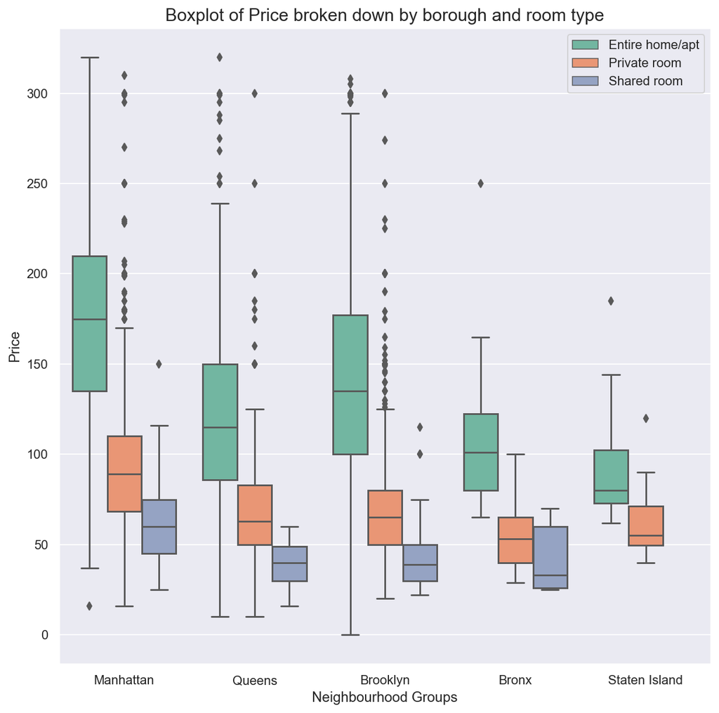

```python
sns.boxplot(df_airbnb['neighbourhood_group'],df_airbnb['price_per_night'],hue = df_airbnb['room_type'], palette="Set2")
plt.title('Boxplot of Price broken down by borough and room type', fontsize = 15)
plt.xlabel('Neighbourhood Groups')
plt.ylabel('Price')
plt.legend(bbox_to_anchor=(1, 1))
plt.show();
```

# Conclusions

The predictive model of hotel prices from Airbnb has great applicability for those who either own hotels or are choosing hotels. This can allow for hotel owners to fine tune their prices to predictions based on the features of their listed properties or allow consumers/travelers to make more better calculated and reliable decisions based on their preferred attributes.

```python
df_airbnb.to_csv("data_cleaned.csv", index=False)
```

# References and Acknowledgements

- AirBNB. (2019, August 12). New York City Airbnb Open Data. Kaggle. https://www.kaggle.com/dgomonov/new-york-city-airbnb-open-data
- We were influenced by this stackoverflow code for our outlier code. https://stackoverflow.com/questions/35827863/remove-outliers-in-pandas-dataframe-using-percentiles